# Distribution And Order Statistics

Ashik E Elahi

2024-02-17

##### (ii) Plot the distributions on same graph paper with ($\mu = 4, \sigma^2 = 4), (\mu = 4, \sigma^2 = 9)$, and ($\mu = 4, \sigma^2 = 16)$

##### Solution 1 (i):

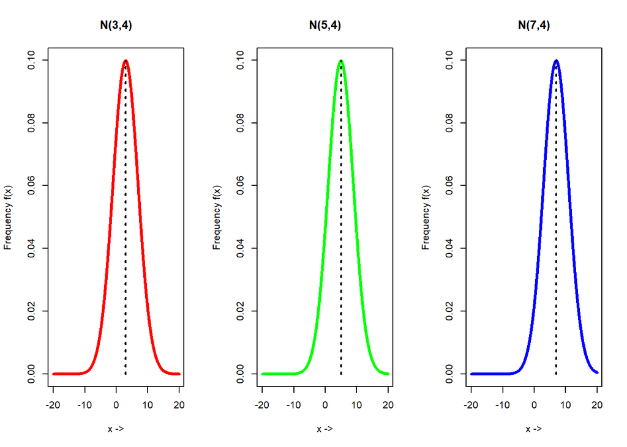

```r
set.seed(21)
par(mfrow = c(1, 3))
mu <- c(3, 5, 7)
sigma.2 <- c(16, 16, 16)
sigma <- sqrt(sigma.2)
colors <- c("red", "green", "blue")
labels <- paste0("N(", mu, ",", sigma, ")")
x <- seq(-20, 20, 0.01)

for(i in 1:length(mu)) {
  fx <- dnorm(x, mean = mu[i], sd = sigma[i])
  plot(x, fx, type="l", col = colors[i], lwd=3,
      main = labels[i], xlab = "x ->",
      ylab = "Frequency f(x)")

  segments(x0 = mu[i], y0 = 0, x1 = mu[i], y1 = max(fx), lwd = 2, lty=3)
}
```

##### Solution 1 (ii):

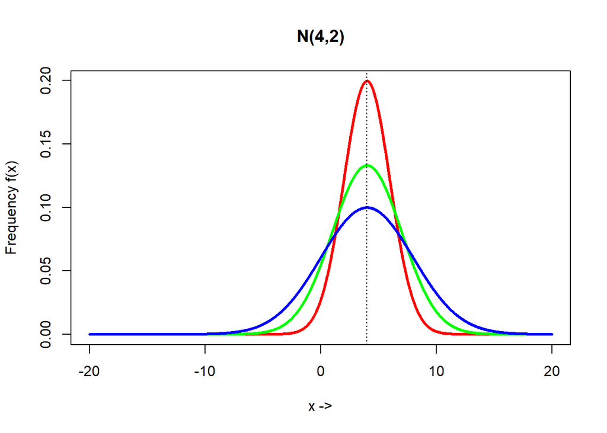

```r
set.seed(2112)
mu <- c(4, 4, 4)
sigma.2 <- c(4, 9, 16)
sigma <- sqrt(sigma.2)
colors <- c("red", "green", "blue")
labels <- paste0("N(", mu, ",", sigma, ")")
x <- seq(-20, 20, 0.01)

for(i in 1:length(mu)) {
  fx <- dnorm(x, mean = mu[i], sd = sigma[i])
  if(i == 1) {
    plot(x, fx, type="l", col = colors[i], lwd=3,
        main = labels[i], xlab = "x ->",
        ylab = "Frequency f(x)")
  } else {
    lines(x, fx, lwd=3, col=colors[i])
  }
}
abline(v=mu[1], lty=3)
```

##### **Method - 1:**

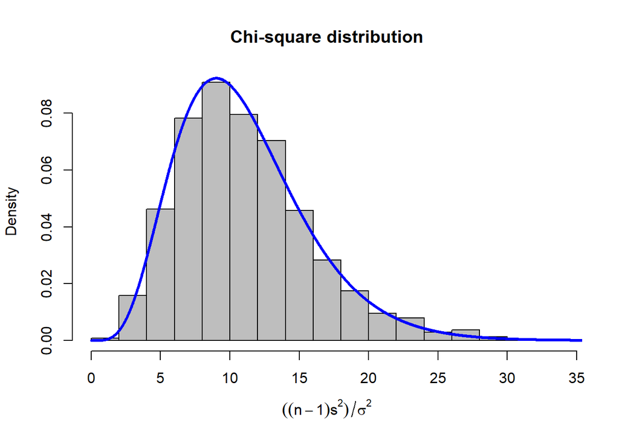

```r
set.seed(221)
par(mfrow=c(1, 1))
n = 12
mu = 4
sigma = sqrt(9)
it = 1200

xvar = array()
for(i in 1:it) {
  x = rnorm(n, mu, sigma)
  xvar[i] = var(x)
}
# xvar -> list of variances

x = ((n-1)*xvar)/sigma^2
hist(x, breaks = 15, freq = F, col = "gray", xlab = expression(((n-1)*s^2)/sigma^2), main="Chi-square distribution")

x.2 = seq(0,120, 0.01)
chisq.pdf = dchisq(x.2, df=n-1)
lines(x.2, chisq.pdf, col="blue", lwd=3)
```

##### **Method - 2:**

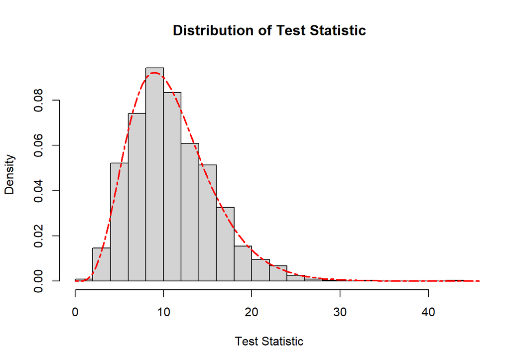

```r
set.seed(11)
#Generate 1200 random sample of size 12
n = 12
mu = 2
sigma = sqrt(9)

samples <- replicate(1200, rnorm(n, mean = mu, sd = sigma))
# samples

# apply(samples, 2, var)

#Calculate the test statistic for each sample
test_statistic <- (n-1)*(apply(samples, 2, var)/sigma^2)


hist(test_statistic, breaks = 25, probability= TRUE,
     main = "Distribution of Test Statistic",
     xlab="Test Statistic",
     ylab="Density")

# Plot the chi-square distribution with (n-1) degrees of freedom
x <- seq(0, max(test_statistic)+5, length.out = 100)
lines(x, dchisq(x, df=n-1), col="red", lwd=2, lty=6)
```

```r
#dchisq(x, df=n-1)
```

##### Problem 3: A random sample of size 4 is drawn from a population that has a uniform distribution on the interval (0, 5). The resulting order statistics are $X_{1:4}, X_{2:4}, X_{3:4}$ and $X_{4:4}$. Determine the cumulative distribution function (CDF) of the $3^{rd}$ order statistics $(X_{3:4})$ and plot the CDF of the $3^{rd}$ order statistic. Evaluate the probability $P[X_{3:4} >= 2]$

###### Method - 1:

```r
cdf_uniform <- function(x, a, b) {
  ifelse(x < 0, 0, ifelse(x > 5, 1, (x-a)/(b-a)))
}

Fr_n_eqn <- function(x, r, n) {
  sum_eqn <- ""
  for(j in r:n) {
    term <- paste0("(", n, "C", j, ")", "F(x)^", j, "[1-F(x)]^(",n, "-", j, ")")
    if(j < n) {
      sum_eqn = paste0(sum_eqn, term, "+")
    } else {
      sum_eqn = paste0(sum_eqn, term)
    }
  }
  return(sum_eqn)
}

Fr_n_value <- function(x, r, n, a, b) {
  cdf_x = cdf_uniform(x, a, b)
  sum_value = 0

  for(j in r:n) {
    sum_value = sum_value + choose(n, j)*(cdf_x^j)*(1-cdf_x)^(n-j)
  }
  return(sum_value)
}


# Results

r <- 3
n <- 4
a <- 0
b <- 5
x <- seq(a, b, length.out=100)

Fr_n_equation <- Fr_n_eqn(x, r, n)
Fr_n_values <- Fr_n_value(x, r, n, a, b)



cat("The distribution function F", r, ":", n, "(x) is given by :\n", Fr_n_equation)
```

```
## The distribution function F 3 : 4 (x) is given by :
##  (4C3)F(x)^3[1-F(x)]^(4-3)+(4C4)F(x)^4[1-F(x)]^(4-4)
```

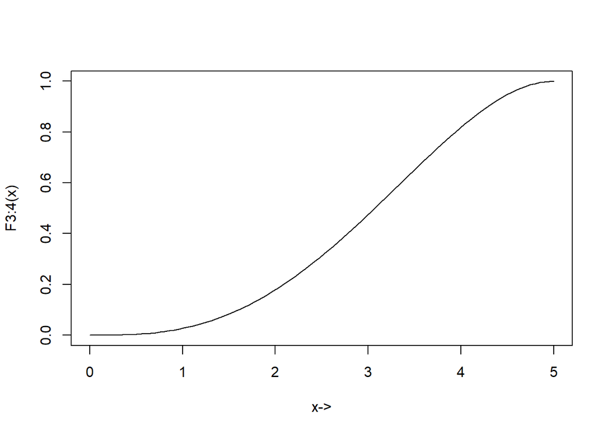

```r
plot(x, Fr_n_values, type="l", xlab = "x->", ylab = paste0("F", r, ":", n, "(x)"))
```

```r
# P(x_3:4 > 2)
x_threshold <- 2
p_x3_gt_x <- 1 - Fr_n_value(x_threshold, r, n, a, b)
p_x3_gt_x
```

```
## [1] 0.8208
```

##### Problem 4: Suppose $X_{1:7} < X_{2:7} < X_{3:7} < X_{4:7} < X_{5:7} < X_{6:7} < X_{7:7}$ denote the order statistics based on a random sample of size 7 from the distribution having probability density function (pdf) $f(x) = \frac{1}{10}, 0 \leq x \leq 10$. Evaluate the mean and variance of the $5^{th}$ order statistic $(X_{5:7})$ and plot the CDF of the $5^{th}$ order statistic.

```r
cdf_dis = function(x, a, b) {
  ifelse(x < a, 0, ifelse(x > b, 1, x / 10))
}

# pdf of order statistic
fr_n = function(x, r, n, a, b) {
  cdf_x = cdf_dis(x, a, b)
  pdf_x = 0.1

  numerator <- factorial(n) / (factorial(r-1)*factorial(n-r))
    prob_dist <- numerator * cdf_x^(r-1) * (1 - cdf_x)^(n-r)*pdf_x
    prob_dist
}

a = 0
b = 10
r = 5
n = 7

moment_k <- function(k, r, n, a, b) {
    integrand <- function(x) x^k * fr_n(x, r, n, a, b)
    moment <- integrate(integrand, a, b)$value
    moment
}

mean_x5 <- moment_k(1, r, n, a, b)
var_x5 <- moment_k(2, r, n, a, b) - mean_x5^2


cat("Mean of X_{(5)}:", mean_x5, "\n")
```

```
## Mean of X_{(5)}: 6.25
```

```r
cat("Variance of X_{(5)}:", var_x5, "\n")
```

```
## Variance of X_{(5)}: 2.604167
```

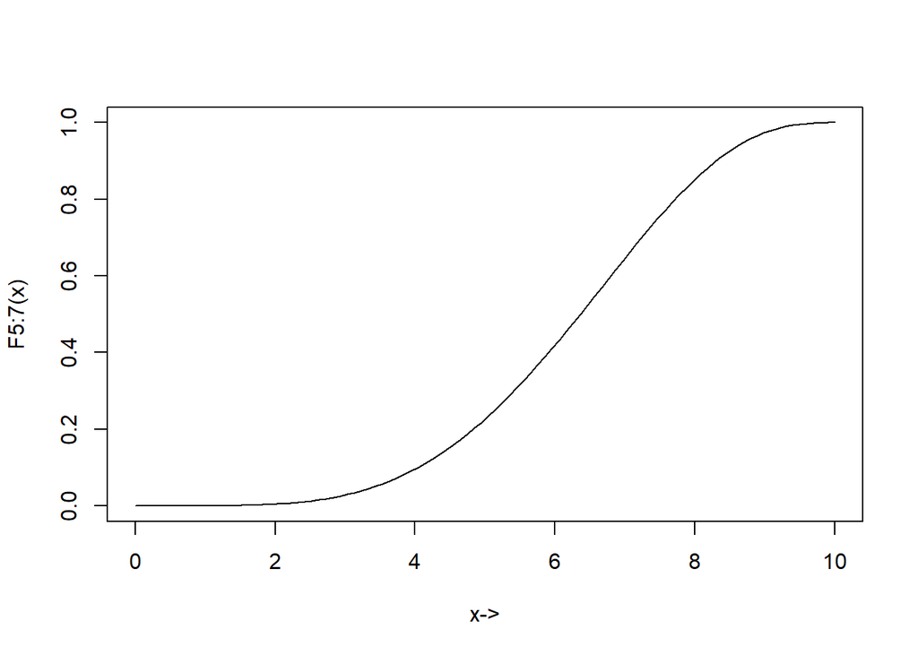

```r
x_values = seq(a, b, length.out=100)
Fr_n_values = array()
for(i in 1:100) {
  Fr_n_values[i] = integrate(fr_n, a, x_values[i], r=r, n=n, a=a,  b=b)$value
}

plot(x_values, Fr_n_values, type = "l", xlab = "x->", ylab=paste0("F", r, ":", n, "(x)"))
```

##### Problem 5 A random sample of size 3 is drawn from a population that has a uniform distribution on the interval (0, 1). The resulting order statistics are $X_{1:3}, X_{2:3}$ and $X_{3:3}$. Determine the mean and variance of smallest and largest order statistic.

##### **Method 1:**

```r
# kth moment of rth order statistic  = (3!*(k+r-1)!) / ((r-1)! * (k+3)!)
rm_uniform_order <- function(k, r) {
  (factorial(3)*factorial(k+r-1)) / (factorial(r-1)*factorial(k+3))
}

mean_X_1.3 = rm_uniform_order(k = 1, r = 1)
 var_X_1.3 = rm_uniform_order(k = 2, r = 1) - mean_X_1.3^2
mean_X_3.3 = rm_uniform_order(k = 1, r = 3)
 var_X_3.3 = rm_uniform_order(k = 2, r = 3) - mean_X_3.3^2

mean_X_1.3
```

```
## [1] 0.25
```

```r
var_X_1.3
```

```
## [1] 0.0375
```

```r
mean_X_3.3
```

```
## [1] 0.75
```

```r
var_X_3.3
```

```
## [1] 0.0375
```

##### **Method 2**

```r
# kth moment of rth roder statistic when sample size is n
# PI_i=1^k ((r+i) / (n+i))
rm_uniform_order_n <- function(n, r, k) {
  mult = 1
  for(i in 1:k) {
    term = (r+i-1) / (n+i)
    mult = mult * term
  }
  return(mult)
}
mean_X_1.3 = rm_uniform_order_n(n = 3, r = 1, k = 1)
 var_X_1.3 = rm_uniform_order_n(n = 3, r = 1, k = 2) - mean_X_1.3^2
mean_X_3.3 = rm_uniform_order_n(n = 3, r = 3, k = 1)
 var_X_3.3 = rm_uniform_order_n(n = 3, r = 3, k = 2) - mean_X_3.3^2

mean_X_1.3
```

```
## [1] 0.25
```

```r
var_X_1.3
```

```
## [1] 0.0375
```

```r
mean_X_3.3
```

```
## [1] 0.75
```

```r
var_X_3.3
```

```
## [1] 0.0375
```

##### Problem 6: The random sample $X_1, X_2, ..., X_9$ of size 9 is drawn from a population that has a uniform distribution with the interval (0, 10). Evaluate the mean and variance of 7th order statistic.

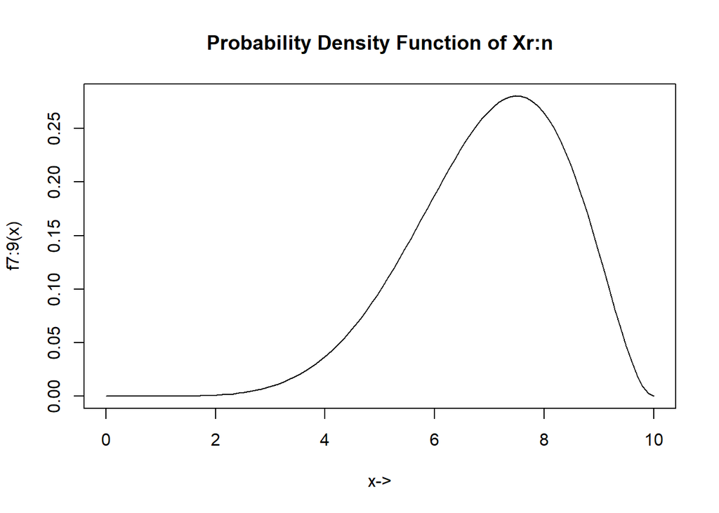

```r
# cdf
cdf_uniform <- function (x, a, b) {
    ifelse(x < a, 0, ifelse(x > b, 1, (x - a) / (b - a)))
}

# fr:n
fr_n <- function (x, r, n, a, b) {
    cdf_x <- cdf_uniform(x, a, b)
    pdf_x <- 1 / (b - a)

    numerator <- factorial(n) / (factorial(r-1)*factorial(n-r))
    prob_dist <- numerator * cdf_x^(r-1) * (1 - cdf_x)^(n-r)*pdf_x
    prob_dist
}


a <- 0
b <- 10
n <- 9
r <- 7

x_values <- seq(a, b, length.out=100)

fr_n_values <- sapply(x_values, fr_n, r=r, n=n, a=a, b=b)

plot(x_values, fr_n_values, type="l", ylim=c(0, max(fr_n_values)), xlab="x->", ylab=paste0("f", r, ":", n, "(x)"), main=paste0("Probability Density Function of Xr:n"))
```

```r
# int 2 to 10
p_x7_gt_2 <- integrate(fr_n, 2, b, r=r, n=n, a=a, b=b)$value
cat("P(X_{(7)} > 2):", p_x7_gt_2, "\n")
```

```
## P(X_{(7)} > 2): 0.9996861
```

```r
moment_k <- function(k, r, n, a, b) {
    integrand <- function(x) x^k * fr_n(x, r, n, a, b)
    moment <- integrate(integrand, a, b)$value
    moment
}

mean_x7 <- moment_k(1, r, n, a, b)
var_x7 <- moment_k(2, r, n, a, b) - mean_x7^2


cat("Mean of X_{(7)}:", mean_x7, "\n")
```

```
## Mean of X_{(7)}: 7
```

```r
cat("Variance of X_{(7)}:", var_x7, "\n")
```

```
## Variance of X_{(7)}: 1.909091
```